# s01_explore_phenotypes

started: AL20Sep2018  
last updated: AL18Sep2019

# Summary

Explore phenotype features and balance between cases and controls

Input and output:  
- WECARE-NFE dataset of 1,503 variants x 664 samples (467BC = 232UBC + 235CBC and 197NFE)

## Findings:

Ampliseq is slightly older than WES dataset: 50 vs 42 yrs respectively;  
although no difference in ade between cases and controls (because the controld were matched)

No association of CBC with familial history (there was a non-significant trend in WES)

The only statisitically significant association was with the applied treatment:  
there was less treatment in CBC in any modality of treatment (consistent with WES).

This might possibly be explained by the fact that more cases with radiotherapy  
were deliberately selected for UBC, as a part of “counter-matching” samples collection.

If there was no “countermatching” explanations, then such trend could be interpreted  
in a “reverse-causality” way: as if the treatment protected from CBC, and also might possibly be linked  
to the trend of having earlier stages in 1st tumour in CBC (less lymph node involvement),  
**possibly indicating to undrtreatment of the tumours at early stage**.  
This speculation could be consistent with the fact that  
**Nearly a quater of the CBC were treated by surgery alone (w/o chemo- or hormonal- treatment)**  
this was in fasion over the recent decade - but wecare was collected earlier?

There was outdated hormonal treatment pratices  
- Nearly half of ER+ve patients did not receive hormonal treatment  
- 23 ER-ve patients received the hormopnal treatment  
- a significant proportion of cases has unknown HR

CBC tumours were at slightly earlier stage (with less lymph nodes involvement), but less differentialted.  
All these trends were not significant.

The potential association of stage/LN and CBC might be mediated by reduced treatment?

Interestingly, there was no association with pregnancies (in contrast with the WES dataset)  
There was an odd case with 14 ftp at 48 years … mitigated by coding of fpt

As expected, NS trend for more lobular in CBC

A suggestive association of CBC and UBC with sample number (t-test 0.06)  
obviously illustrates the possibility of spurious associations

Any differences between CBC and UBC, even statistically significant, were modest in size

At the end I illustrated manual control of colours and factors orders on many occasions  
https://stackoverflow.com/questions/25211078/what-are-the-default-plotting-colors-in-r-or-ggplot2

# Point to discuss with MT:

Should we include X-ray treatment into the model?  
My suggestion is NOT to include X-ray into the model  
for compartibility with WES analysis  
(which is fixed after it was used for candidate genes selection)

# start_section

```r
Sys.time()
```

```
## [1] "2019-09-18 16:05:17 BST"
```

```r
rm(list=ls())
graphics.off()

library(knitr)
library(dplyr)
library(ggplot2)
#library(tidyr) # for separate (for VEP parsing)

base_folder="/Users/alexey/Documents/wecare/ampliseq/v04_ampliseq_nfe/s14_explore_phenotypes"
opts_knit$set(root.dir = base_folder)

options(stringsAsFactors = F)
options(warnPartialMatchArgs = T,
        warnPartialMatchAttr = T,
        warnPartialMatchDollar = T)

#options(error = browser()) # Type Q or c to exit, drop browser level
# https://support.rstudio.com/hc/en-us/articles/200713843?version=1.1.456&mode=desktop
# https://stackoverflow.com/questions/13052522/how-to-leave-the-r-browser-mode-in-the-console-window/13052588
```

# read_data

```r
source_folder="/Users/alexey/Documents/wecare/ampliseq/v04_ampliseq_nfe/s13_ampliseq-nfe_only_PCA/s03_explore_PCA_plots_exclude_outliers"
load(paste(source_folder, "s03_exclude_outliers_recalculate_acanaf.RData", sep="/"))
base_folder="/Users/alexey/Documents/wecare/ampliseq/v04_ampliseq_nfe/s14_explore_phenotypes"
rm(source_folder)
```

# Check data

```r
ls()
```

```
## [1] "base_folder"   "genotypes.mx"  "phenotypes.df" "variants.df"
```

```r
dim(genotypes.mx)
```

```
## [1] 1503  664
```

```r
dim(phenotypes.df)
```

```
## [1] 664  31
```

```r
dim(variants.df)
```

```
## [1] 1503   80
```

```r
sum(colnames(genotypes.mx) != rownames(phenotypes.df))
```

```
## [1] 0
```

```r
sum(rownames(genotypes.mx) != rownames(variants.df))
```

```
## [1] 0
```

# Exclude NFE phenotypes

```r
table(phenotypes.df$cc)
```

```
##
##  -1   0   1
## 197 232 235
```

```r
phenotypes.df <- phenotypes.df[phenotypes.df$cc != -1,]
table(phenotypes.df$cc)
```

```
##
##   0   1
## 232 235
```

```r
dim(phenotypes.df)
```

```
## [1] 467  31
```

# Highly significant association of XRT with CC

Most likely it is a consequence of the “counter-matched” design of the samples selection

```r
colnames(phenotypes.df)
```

```
##  [1] "long_ids"         "illumina_id"      "illumina_lane"
##  [4] "Sample_num"       "cc"               "rstime"
##  [7] "sub_dx_age"       "hormone_self_mra" "chemo_self_mra"
## [10] "treatment"        "Hist_lob_other"   "stage_fd"
## [13] "histo1_cat"       "er1_cat"          "pr1_cat"
## [16] "grade1"           "Lnsum1_cat"       "Tusize1_cat"
## [19] "Num_ftp_fd"       "rh_num_ftp_fd_rd" "num_ftp_rd"
## [22] "family_history"   "setno"            "xrtbreast"
## [25] "group"            "sample_id"        "PC1"
## [28] "PC2"              "PC3"              "PC4"
## [31] "PC5"
```

```r
cc_rt.df <- phenotypes.df[, c("cc", "xrtbreast")]
str(cc_rt.df)
```

```
## 'data.frame':    467 obs. of  2 variables:
##  $ cc       : int  0 0 0 1 0 0 0 1 1 1 ...
##  $ xrtbreast: int  1 1 1 0 1 0 1 0 1 0 ...
```

```r
table(cc_rt.df)
```

```
##    xrtbreast
## cc    0   1
##   0  83 149
##   1 150  85
```

```r
fisher.test(table(cc_rt.df))
```

```
##
##  Fisher's Exact Test for Count Data
##
## data:  table(cc_rt.df)
## p-value = 1.465e-09
## alternative hypothesis: true odds ratio is not equal to 1
## 95 percent confidence interval:
##  0.2124208 0.4687118
## sample estimates:
## odds ratio
##  0.3164912
```

```r
rm(cc_rt.df)
```

# Demographics

## sub_dx_age

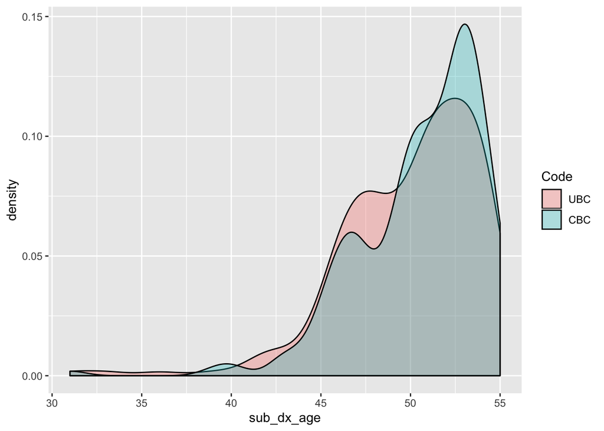

```r
ggplot(phenotypes.df) +
  aes(sub_dx_age, fill=as.factor(cc)) +
  geom_density(colour="black", alpha=0.3) +
  scale_fill_discrete(name="Code", labels=c("UBC", "CBC"))
```

```r
quantile(phenotypes.df$sub_dx_age)
```

```
##   0%  25%  50%  75% 100%
##   31   48   51   53   55
```

```r
mean(phenotypes.df$sub_dx_age)
```

```
## [1] 50.2955
```

```r
t.test(sub_dx_age~cc, data=phenotypes.df)
```

```
##
##  Welch Two Sample t-test
##
## data:  sub_dx_age by cc
## t = -1.6164, df = 460.12, p-value = 0.1067
## alternative hypothesis: true difference in means is not equal to 0
## 95 percent confidence interval:
##  -1.2062526  0.1174412
## sample estimates:
## mean in group 0 mean in group 1
##        50.02155        50.56596
```

## rstime

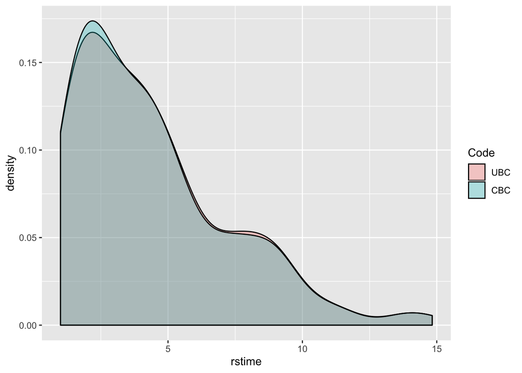

```r
ggplot(phenotypes.df) +
  aes(rstime, fill=as.factor(cc)) +
  geom_density(colour="black", alpha=0.3) +
  scale_fill_discrete(name="Code", labels=c("UBC", "CBC"))
```

```r
mean(phenotypes.df$rstime)
```

```
## [1] 4.398201
```

```r
median(phenotypes.df$rstime)
```

```
## [1] 3.83
```

```r
t.test(rstime~cc, data=phenotypes.df)
```

```
##
##  Welch Two Sample t-test
##
## data:  rstime by cc
## t = 0.14892, df = 464.87, p-value = 0.8817
## alternative hypothesis: true difference in means is not equal to 0
## 95 percent confidence interval:
##  -0.4844179  0.5638610
## sample estimates:
## mean in group 0 mean in group 1
##        4.418190        4.378468
```

## Familial history

Balanced between UBC and CBC

```r
x <- table(phenotypes.df[,c("cc","family_history")])
x
```

```
##    family_history
## cc   1+ adopted none
##   0  64       7  161
##   1  63       7  165
```

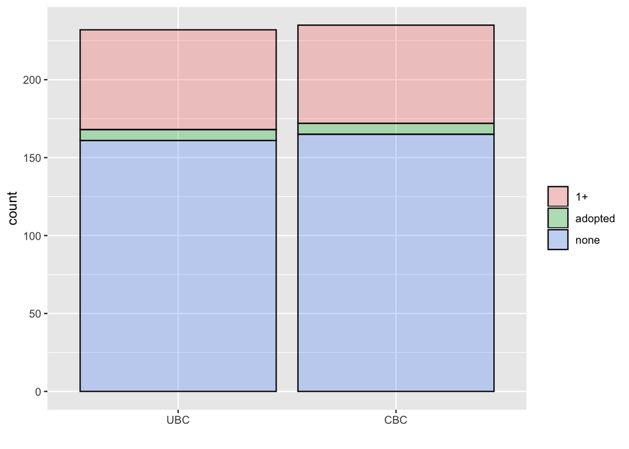

```r
ggplot(phenotypes.df) +
  aes(as.factor(cc), fill=as.factor(family_history)) +
  geom_bar(colour="black", alpha=0.3) +
  scale_x_discrete(name ="", labels=c("0" = "UBC", "1" = "CBC")) +
  scale_fill_discrete(name="")
```

```r
chisq.test(x,simulate.p.value=TRUE)
```

```
##
##  Pearson's Chi-squared test with simulated p-value (based on 2000
##  replicates)
##
## data:  x
## X-squared = 0.037683, df = NA, p-value = 0.9845
```

```r
fisher.test(x,simulate.p.value=TRUE)
```

```
##
##  Fisher's Exact Test for Count Data with simulated p-value (based
##  on 2000 replicates)
##
## data:  x
## p-value = 0.986
## alternative hypothesis: two.sided
```

```r
rm(x)
```

## Num ftp

Number of pregnancies

```r
# Pregnancies counts at different time points
summary(as.factor(phenotypes.df$Num_ftp_fd)) # Pregnancies before the 1st Ds
```

```
##  -1   0   1   2   3   4   5   6   7  14
##  54  19  59 164 112  39  13   3   3   1
```

```r
summary(as.factor(phenotypes.df$rh_num_ftp_fd_rd)) # Pregnancies between Ds1 and Rs time
```

```
##   0
## 467
```

```r
summary(as.factor(phenotypes.df$num_ftp_rd)) # Pregnancies at Rs time
```

```
##  -1   0   1   2   3   4   5   6   7  14
##  54  19  59 164 112  39  13   3   3   1
```

```r
sum(phenotypes.df$Num_ftp_fd != phenotypes.df$num_ftp_rd)
```

```
## [1] 0
```

```r
# Exclude excessive annotations and rename the retained
phenotypes.df <- phenotypes.df %>%
  rename(num_ftp=num_ftp_rd) %>%
  select(-Num_ftp_fd, -rh_num_ftp_fd_rd)

x <- table(phenotypes.df[,c("cc","num_ftp")])
x
```

```
##    num_ftp
## cc  -1  0  1  2  3  4  5  6  7 14
##   0 27  7 30 85 51 21  8  2  0  1
##   1 27 12 29 79 61 18  5  1  3  0
```

```r
chisq.test(x,simulate.p.value=TRUE)
```

```
##
##  Pearson's Chi-squared test with simulated p-value (based on 2000
##  replicates)
##
## data:  x
## X-squared = 7.6826, df = NA, p-value = 0.5927
```

```r
fisher.test(x,simulate.p.value=TRUE)
```

```
##
##  Fisher's Exact Test for Count Data with simulated p-value (based
##  on 2000 replicates)
##
## data:  x
## p-value = 0.6097
## alternative hypothesis: two.sided
```

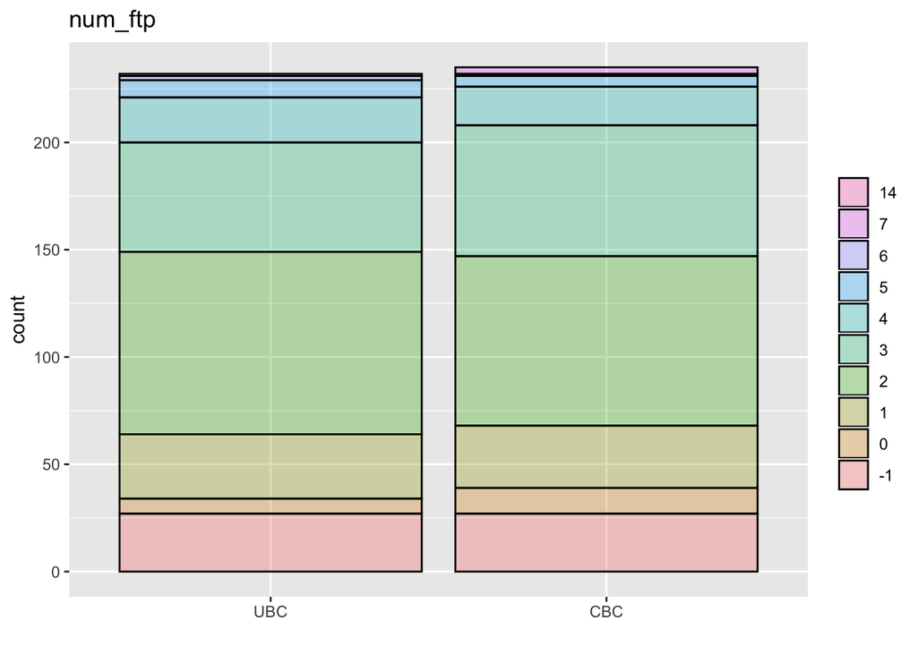

```r
ggplot(phenotypes.df) +
  aes(as.factor(cc),
      fill=factor(num_ftp, levels=c(14,7,6,5,4,3,2,1,0,-1))) +
  geom_bar(colour="black", alpha=0.3) +
  scale_x_discrete(name ="", labels=c("0" = "UBC", "1" = "CBC")) +
  scale_fill_manual(name="",
    values = c("-1"="#F8766D",
                "0"="#D89000",
                "1"="#A3A500",
                "2"="#39B600",
                "3"="#00BF7D",
                "4"="#00BFC4",
                "5"="#00B0F6",
                "6"="#9590FF",
                "7"="#E76BF3",
               "14"="#FF62BC")) +
  ggtitle("num_ftp")
```

```r
# An unusual case...
phenotypes.df[phenotypes.df$num_ftp==14,c("num_ftp","sub_dx_age")]
```

```
##               num_ftp sub_dx_age
## 126_S171_L007      14         48
```

```r
rm(x)
```

## Coded number of pregnancies

```r
num_preg <- rep(NA, nrow(phenotypes.df))

0 -> num_preg[phenotypes.df$num_ftp %in% c(-1,0)] # Never pregnant and non-fulltime pregnancy
1 -> num_preg[phenotypes.df$num_ftp %in% c(1,2,3)]
2 -> num_preg[phenotypes.df$num_ftp %in% c(4,5,6,7,14)]

phenotypes.df <- cbind(phenotypes.df,num_preg)

x <- table(phenotypes.df[,c("cc","num_preg")])
x
```

```
##    num_preg
## cc    0   1   2
##   0  34 166  32
##   1  39 169  27
```

```r
chisq.test(x,simulate.p.value=TRUE)
```

```
##
##  Pearson's Chi-squared test with simulated p-value (based on 2000
##  replicates)
##
## data:  x
## X-squared = 0.77382, df = NA, p-value = 0.6997
```

```r
fisher.test(x,simulate.p.value=TRUE)
```

```
##
##  Fisher's Exact Test for Count Data with simulated p-value (based
##  on 2000 replicates)
##
## data:  x
## p-value = 0.6867
## alternative hypothesis: two.sided
```

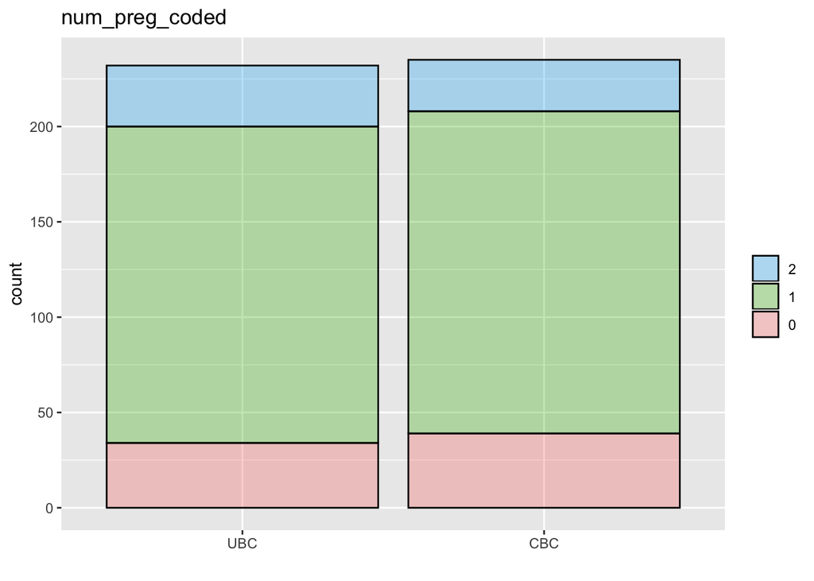

```r
ggplot(phenotypes.df) +
  aes(as.factor(cc),
      fill=factor(num_preg, levels=c(2,1,0))) +
  geom_bar(colour="black", alpha=0.3) +
  scale_x_discrete(name ="", labels=c("0" = "UBC", "1" = "CBC")) +
  scale_fill_manual(name="",
    values = c("0"="#F8766D",
                "1"="#39B600",
                "2"="#00B0F6")) +
  ggtitle("num_preg_coded")
```

```r
rm(x, num_preg)
```

# Clinical data

## stage_fd

NS trend to earlier stage (less size and lymph nodes) in CBC

### p~0.08

```r
summary(as.factor(phenotypes.df$stage_fd))
```

```
##   1   2
## 332 135
```

```r
x <- table(phenotypes.df[,c("cc","stage_fd")])
x
```

```
##    stage_fd
## cc    1   2
##   0 156  76
##   1 176  59
```

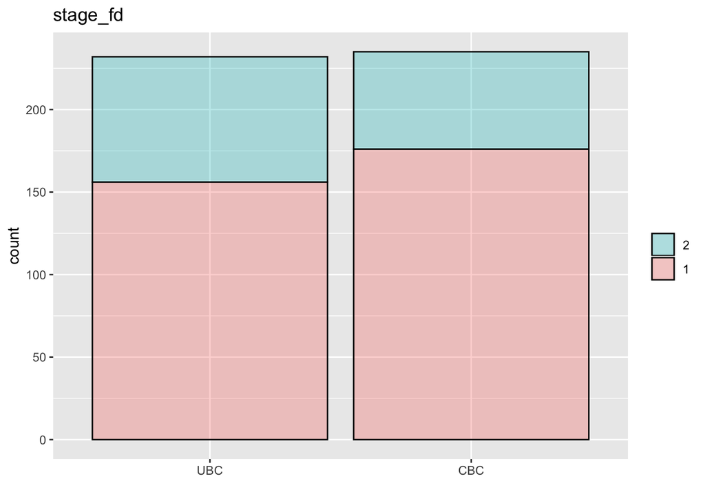

```r
ggplot(phenotypes.df) +
  aes(as.factor(cc), fill=factor(phenotypes.df$stage_fd, levels=c(2,1))) +
  geom_bar(colour="black", alpha=0.3) +
  scale_x_discrete(name ="", labels=c("0" = "UBC", "1" = "CBC")) +
  scale_fill_manual(values = c("2"="#00BFC4", "1"="#F8766D"), name="") +
  ggtitle("stage_fd")
```

```r
chisq.test(x,simulate.p.value=TRUE)
```

```
##
##  Pearson's Chi-squared test with simulated p-value (based on 2000
##  replicates)
##
## data:  x
## X-squared = 3.3264, df = NA, p-value = 0.08896
```

```r
fisher.test(x,simulate.p.value=TRUE)
```

```
##
##  Fisher's Exact Test for Count Data
##
## data:  x
## p-value = 0.08251
## alternative hypothesis: true odds ratio is not equal to 1
## 95 percent confidence interval:
##  0.4503432 1.0495149
## sample estimates:
## odds ratio
##  0.6886619
```

```r
rm(x)
```

## Tusize1_cat

NS trend for unknown size in CBC

```r
summary(as.factor(phenotypes.df$Tusize1_cat))
```

```
## gt10-le20mm      gt20mm      le10mm     unknown
##         188         115         129          35
```

```r
x <- table(phenotypes.df[,c("cc","Tusize1_cat")])
x
```

```
##    Tusize1_cat
## cc  gt10-le20mm gt20mm le10mm unknown
##   0          90     63     65      14
##   1          98     52     64      21
```

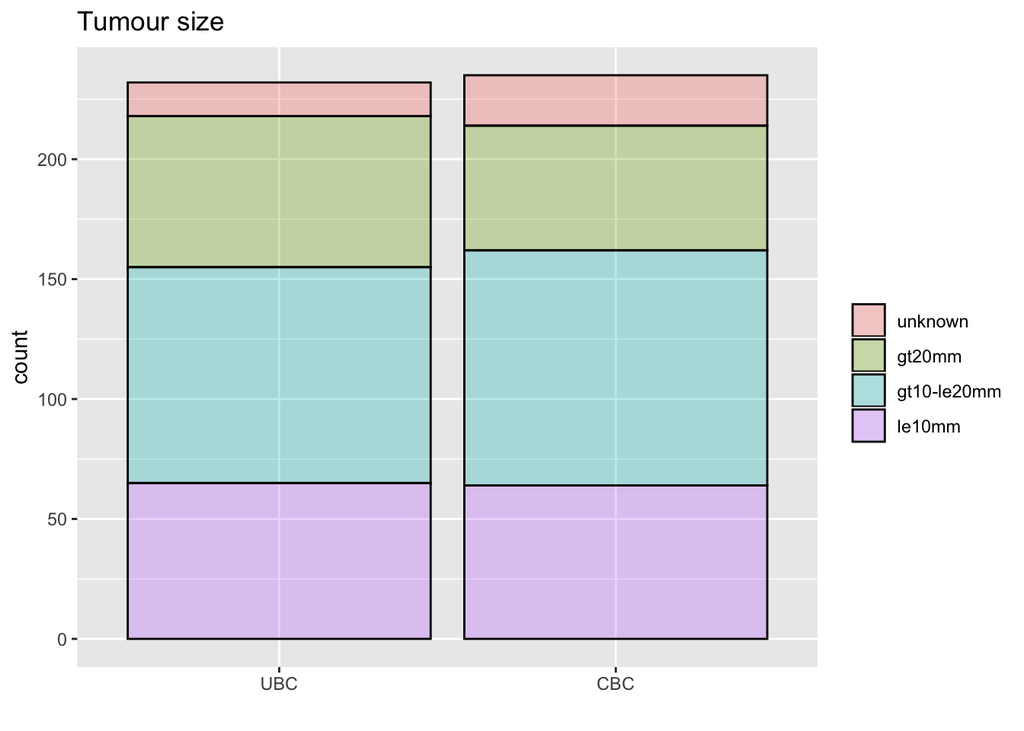

```r
ggplot(phenotypes.df) +
  aes(as.factor(cc), fill=factor(phenotypes.df$Tusize1_cat,
                                 levels=c("inflammatory","unknown","gt20mm","gt10-le20mm","le10mm"))) +
  geom_bar(colour="black", alpha=0.3) +
  scale_x_discrete(name ="", labels=c("0" = "UBC", "1" = "CBC")) +
  scale_fill_discrete(name="") +
  ggtitle("Tumour size")
```

```r
chisq.test(x,simulate.p.value=TRUE)
```

```
##
##  Pearson's Chi-squared test with simulated p-value (based on 2000
##  replicates)
##
## data:  x
## X-squared = 2.7812, df = NA, p-value = 0.4273
```

```r
fisher.test(x,simulate.p.value=TRUE)
```

```
##
##  Fisher's Exact Test for Count Data with simulated p-value (based
##  on 2000 replicates)
##
## data:  x
## p-value = 0.4178
## alternative hypothesis: two.sided
```

```r
rm(x)
```

## Lnsum1_cat

NS trend to less involvement of Lymph-nodes in CBC

```r
summary(as.factor(phenotypes.df$Lnsum1_cat))
```

```
##         negative no nodes sampled         positive          unknown
##              325                9              132                1
```

```r
x <- table(phenotypes.df[,c("cc","Lnsum1_cat")])
x
```

```
##    Lnsum1_cat
## cc  negative no nodes sampled positive unknown
##   0      152                6       74       0
##   1      173                3       58       1
```

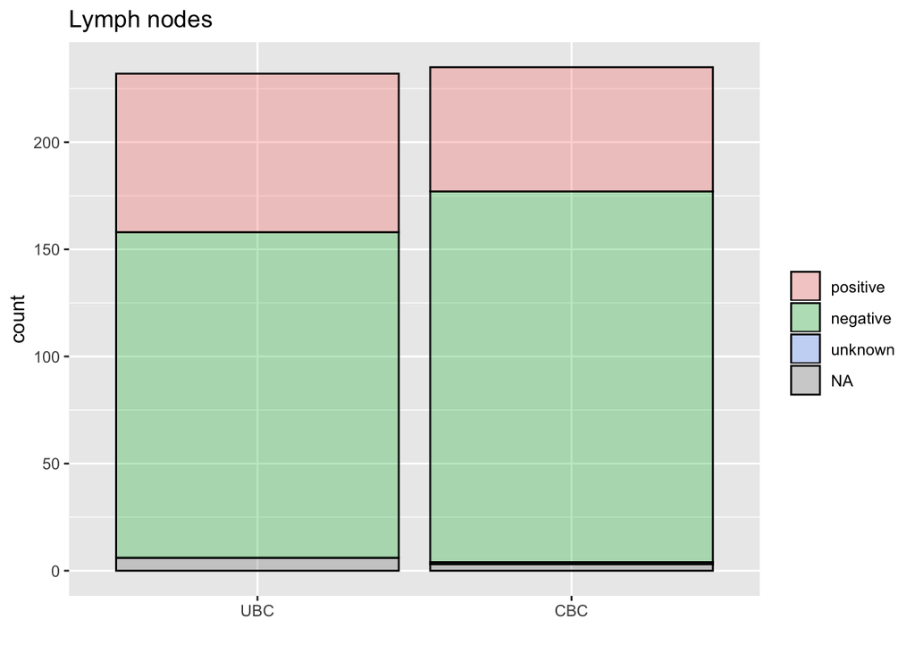

```r
ggplot(phenotypes.df) +
  aes(as.factor(cc), fill=factor(phenotypes.df$Lnsum1_cat,
                                 levels=c("positive","negative","no nores sampled","unknown"))) +
  geom_bar(colour="black", alpha=0.3) +
  scale_x_discrete(name ="", labels=c("0" = "UBC", "1" = "CBC")) +
  scale_fill_discrete(name="") +
  ggtitle("Lymph nodes")
```

```r
chisq.test(x,simulate.p.value=TRUE)
```

```
##
##  Pearson's Chi-squared test with simulated p-value (based on 2000
##  replicates)
##
## data:  x
## X-squared = 5.2773, df = NA, p-value = 0.1014
```

```r
fisher.test(x,simulate.p.value=TRUE)
```

```
##
##  Fisher's Exact Test for Count Data with simulated p-value (based
##  on 2000 replicates)
##
## data:  x
## p-value = 0.1149
## alternative hypothesis: two.sided
```

```r
rm(x)
```

# Cytotoxic or endocrine treatment

**Significantly less** treatment in CBC  
Consistent with WES cohort

## Any/Both

To do: split by age?  
Type of treatment by age?

### p~0.01

```r
summary(as.factor(phenotypes.df$treatment))
```

```
##   0   1
## 187 280
```

```r
x <- table(phenotypes.df[,c("cc","treatment")])
x
```

```
##    treatment
## cc    0   1
##   0  77 155
##   1 110 125
```

```r
data.df <- phenotypes.df %>%
  mutate(tx = hormone_self_mra + chemo_self_mra,
         chx = hormone_self_mra + chemo_self_mra + xrtbreast)

summary(as.factor(data.df$tx))
```

```
##   0   1   2
## 187 198  82
```

```r
y <- table(data.df[,c("cc","tx")])
y
```

```
##    tx
## cc    0   1   2
##   0  77 108  47
##   1 110  90  35
```

```r
summary(as.factor(data.df$chx))
```

```
##   0   1   2   3
##  97 186 142  42
```

```r
z<- table(data.df[,c("cc","chx")])
z
```

```
##    chx
## cc    0   1   2   3
##   0  29  85  88  30
##   1  68 101  54  12
```

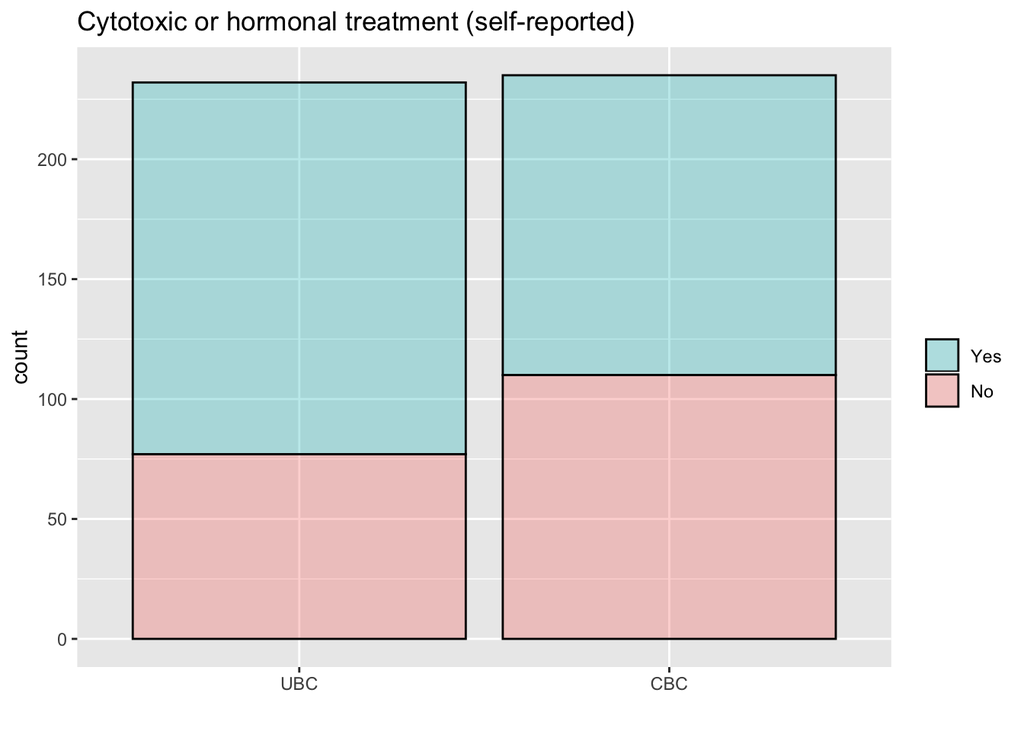

```r
ggplot(phenotypes.df) +
  aes(as.factor(cc), fill=factor(phenotypes.df$treatment, levels=c(1,0))) +
  geom_bar(colour="black", alpha=0.3) +
  scale_x_discrete(name ="", labels=c("0" = "UBC", "1" = "CBC")) +
  scale_fill_manual(labels=c("1" = "Yes", "0" = "No"), values = c("1"="#00BFC4", "0"="#F8766D"), name="") +
  ggtitle("Cytotoxic or hormonal treatment (self-reported)")
```

```r
chisq.test(x,simulate.p.value=TRUE)
```

```
##
##  Pearson's Chi-squared test with simulated p-value (based on 2000
##  replicates)
##
## data:  x
## X-squared = 9.0189, df = NA, p-value = 0.005997
```

```r
fisher.test(x,simulate.p.value=TRUE)
```

```
##
##  Fisher's Exact Test for Count Data
##
## data:  x
## p-value = 0.00337
## alternative hypothesis: true odds ratio is not equal to 1
## 95 percent confidence interval:
##  0.3812312 0.8351735
## sample estimates:
## odds ratio
##  0.5652061
```

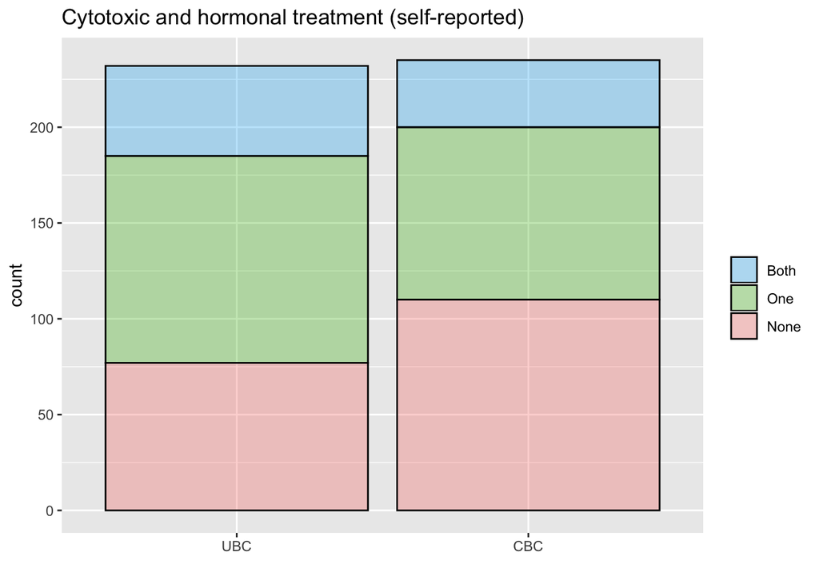

```r
ggplot(data.df) +
  aes(as.factor(cc), fill=factor(data.df$tx, levels=c(2,1,0))) +
  geom_bar(colour="black", alpha=0.3) +
  scale_x_discrete(name ="", labels=c("0" = "UBC", "1" = "CBC")) +
  scale_fill_manual(name="",
                    labels=c("0" = "None", "1" = "One", "2" = "Both"),
                    values=c("0"="#F8766D", "1"="#39B600", "2"="#00B0F6")) +
  ggtitle("Cytotoxic and hormonal treatment (self-reported)")
```

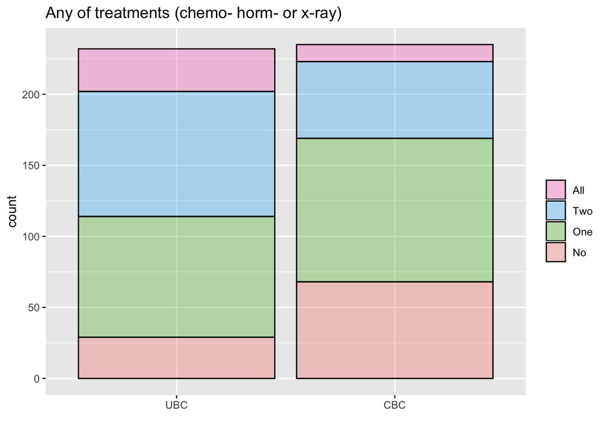

```r
ggplot(data.df) +
  aes(as.factor(cc), fill=factor(data.df$chx, levels=c(3,2,1,0))) +
  geom_bar(colour="black", alpha=0.3) +
  scale_x_discrete(name ="", labels=c("0" = "UBC", "1" = "CBC")) +
  scale_fill_manual(labels=c("3" = "All", "2" = "Two", "1" = "One", "0" = "No"),
                    values = c("3"="#FF62BC", "2"="#00B0F6","1"="#39B600", "0"="#F8766D"),
                    name="") +
  ggtitle("Any of treatments (chemo- horm- or x-ray)")
```

```r
rm(x,y,z,data.df)
```

## hormone_self_mra

Slightly **less** treatment in CBC

```r
summary(as.factor(phenotypes.df$hormone_self_mra))
```

```
##   0   1
## 292 175
```

```r
x <- table(phenotypes.df[,c("cc","hormone_self_mra")])
x
```

```
##    hormone_self_mra
## cc    0   1
##   0 134  98
##   1 158  77
```

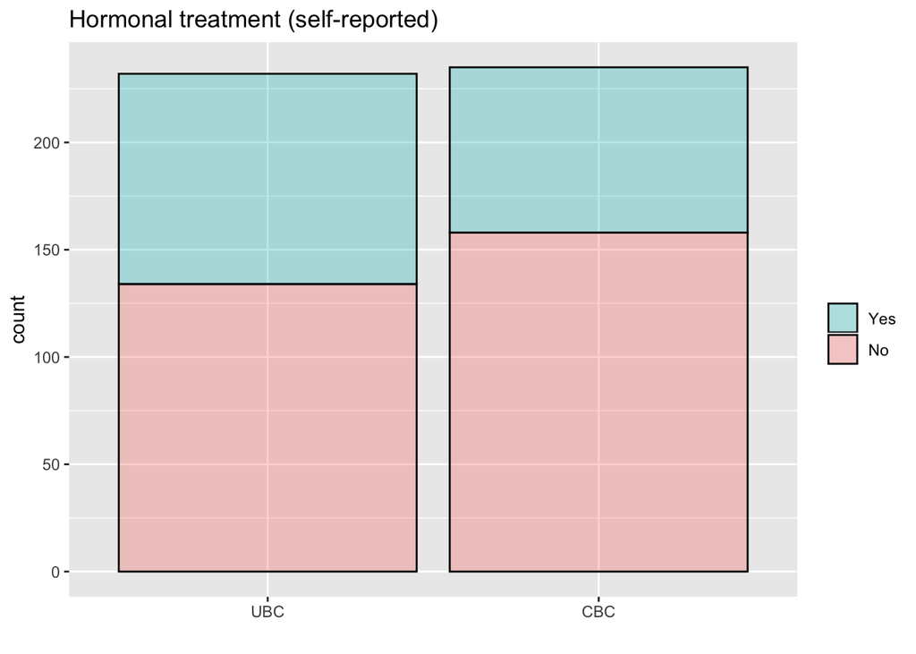

```r
ggplot(phenotypes.df) +
  aes(as.factor(cc), fill=factor(phenotypes.df$hormone_self_mra, levels=c(1,0))) +
  geom_bar(colour="black", alpha=0.3) +
  scale_x_discrete(name ="", labels=c("0" = "UBC", "1" = "CBC")) +
scale_fill_manual(labels=c("1" = "Yes", "0" = "No"), values = c("1"="#00BFC4", "0"="#F8766D"), name="") +
  ggtitle("Hormonal treatment (self-reported)")
```

```r
chisq.test(x,simulate.p.value=TRUE)
```

```
##
##  Pearson's Chi-squared test with simulated p-value (based on 2000
##  replicates)
##
## data:  x
## X-squared = 4.4735, df = NA, p-value = 0.03048
```

```r
fisher.test(x,simulate.p.value=TRUE)
```

```
##
##  Fisher's Exact Test for Count Data
##
## data:  x
## p-value = 0.03595
## alternative hypothesis: true odds ratio is not equal to 1
## 95 percent confidence interval:
##  0.4488742 0.9884700
## sample estimates:
## odds ratio
##  0.6669627
```

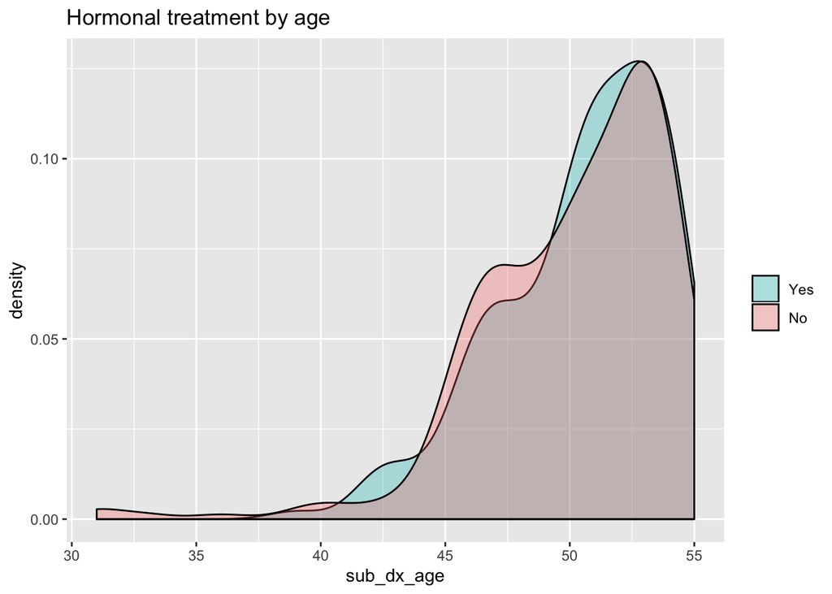

```r
ggplot(phenotypes.df) +
  aes(x = sub_dx_age, fill=factor(phenotypes.df$hormone_self_mra, levels=c(1,0))) +
  geom_density(colour="black", alpha=0.3) +
  scale_fill_manual(labels=c("1" = "Yes", "0" = "No"), values = c("1"="#00BFC4", "0"="#F8766D"), name="") +
  ggtitle("Hormonal treatment by age")
```

```r
# Somehow unexpected and outdated hormonal treatment pratices
# - Nearly half of ER+ve patients did not receive hormonal treatment
# - 23 ER-ve patients received the hormopnal treatment
# - a significant proportion of cases has unknown HR
table(phenotypes.df[,c("er1_cat","hormone_self_mra")])
```

```
##           hormone_self_mra
## er1_cat      0   1
##   negative  86  23
##   positive 123 132
##   unknown   83  20
```

```r
rm(x)
```

## chemo_self_mra

Slightly **less** treatment in CBC

### p~0.05

```r
summary(as.factor(phenotypes.df$chemo_self_mra))
```

```
##   0   1
## 280 187
```

```r
x <- table(phenotypes.df[,c("cc","chemo_self_mra")])
x
```

```
##    chemo_self_mra
## cc    0   1
##   0 128 104
##   1 152  83
```

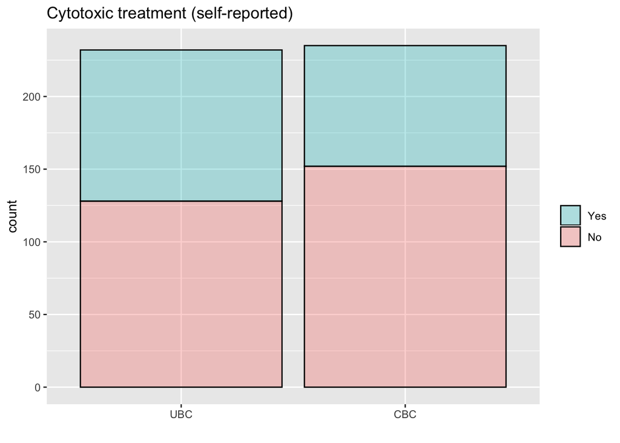

```r
ggplot(phenotypes.df) +
  aes(as.factor(cc), fill=factor(phenotypes.df$chemo_self_mra, levels=c(1,0))) +
  geom_bar(colour="black", alpha=0.3) +
  scale_x_discrete(name ="", labels=c("0" = "UBC", "1" = "CBC")) +
  scale_fill_manual(labels=c("1" = "Yes", "0" = "No"), values = c("1"="#00BFC4", "0"="#F8766D"), name="") +
  ggtitle("Cytotoxic treatment (self-reported)")
```

```r
chisq.test(x,simulate.p.value=TRUE)
```

```
##
##  Pearson's Chi-squared test with simulated p-value (based on 2000
##  replicates)
##
## data:  x
## X-squared = 4.3963, df = NA, p-value = 0.04748
```

```r
fisher.test(x,simulate.p.value=TRUE)
```

```
##
##  Fisher's Exact Test for Count Data
##
## data:  x
## p-value = 0.03815
## alternative hypothesis: true odds ratio is not equal to 1
## 95 percent confidence interval:
##  0.4551675 0.9918371
## sample estimates:
## odds ratio
##  0.6726554
```

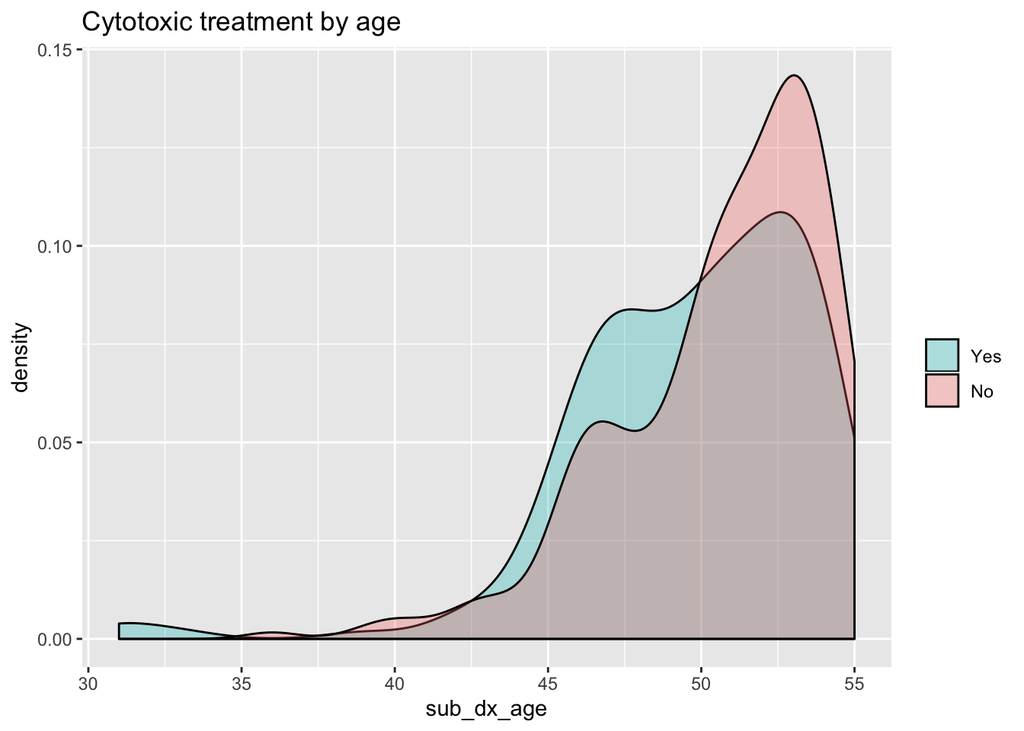

```r
ggplot(phenotypes.df) +
  aes(x = sub_dx_age, fill=factor(phenotypes.df$chemo_self_mra, levels=c(1,0))) +
  geom_density(colour="black", alpha=0.3) +
scale_fill_manual(labels=c("1" = "Yes", "0" = "No"), values = c("1"="#00BFC4", "0"="#F8766D"), name="") +
  ggtitle("Cytotoxic treatment by age")
```

```r
# Expectedly, ER+ve tended to have less cytotoxic treatment
table(phenotypes.df[,c("er1_cat","chemo_self_mra")])
```

```
##           chemo_self_mra
## er1_cat      0   1
##   negative  37  72
##   positive 160  95
##   unknown   83  20
```

```r
rm(x)
```

# X-ray

```r
summary(as.factor(phenotypes.df$xrtbreast))
```

```
##   0   1
## 233 234
```

```r
x <- table(phenotypes.df[,c("cc","xrtbreast")])
x
```

```
##    xrtbreast
## cc    0   1
##   0  83 149
##   1 150  85
```

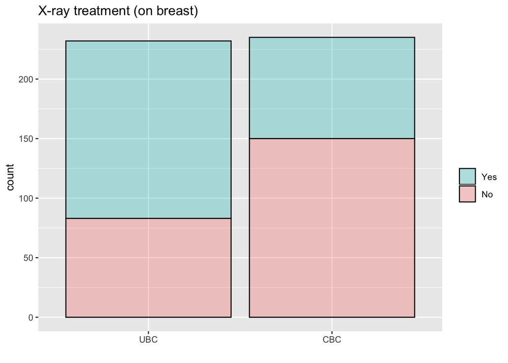

```r
ggplot(phenotypes.df) +
  aes(as.factor(cc), fill=factor(phenotypes.df$xrtbreast, levels=c(1,0))) +
  geom_bar(colour="black", alpha=0.3) +
  scale_x_discrete(name ="", labels=c("0" = "UBC", "1" = "CBC")) +
  scale_fill_manual(labels=c("1" = "Yes", "0" = "No"), values = c("1"="#00BFC4", "0"="#F8766D"), name="") +
  ggtitle("X-ray treatment (on breast)")
```

```r
chisq.test(x,simulate.p.value=TRUE)
```

```
##
##  Pearson's Chi-squared test with simulated p-value (based on 2000
##  replicates)
##
## data:  x
## X-squared = 36.753, df = NA, p-value = 0.0004998
```

```r
fisher.test(x,simulate.p.value=TRUE)
```

```
##
##  Fisher's Exact Test for Count Data
##
## data:  x
## p-value = 1.465e-09
## alternative hypothesis: true odds ratio is not equal to 1
## 95 percent confidence interval:
##  0.2124208 0.4687118
## sample estimates:
## odds ratio
##  0.3164912
```

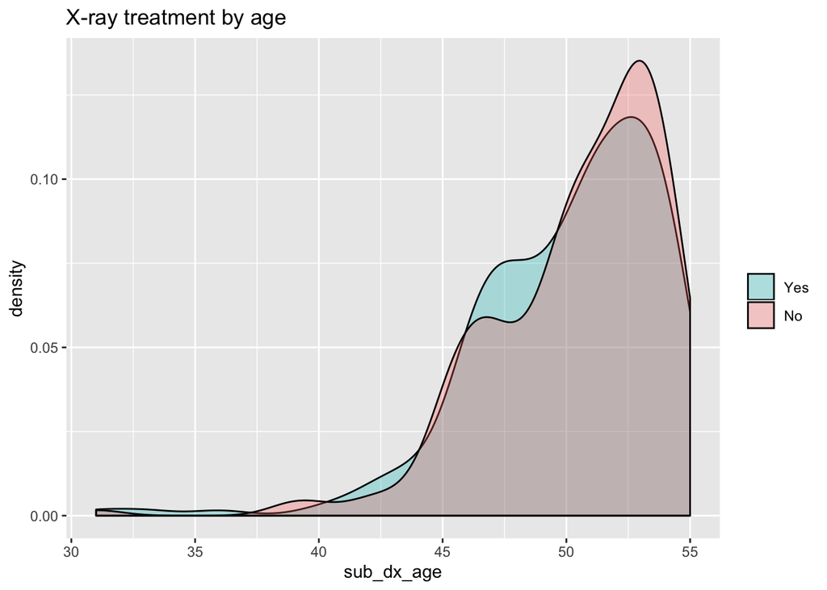

```r
ggplot(phenotypes.df) +
  aes(x = sub_dx_age, fill=factor(phenotypes.df$xrtbreast, levels=c(1,0))) +
  geom_density(colour="black", alpha=0.3) +
scale_fill_manual(labels=c("1" = "Yes", "0" = "No"), values = c("1"="#00BFC4", "0"="#F8766D"), name="") +
  ggtitle("X-ray treatment by age")
```

```r
# Unexpectedly, ER+ve tended to have more X-ray treatment (60 vs 40%)
x <- table(phenotypes.df[,c("er1_cat","xrtbreast")])
x
```

```
##           xrtbreast
## er1_cat      0   1
##   negative  64  45
##   positive 109 146
##   unknown   60  43
```

```r
51/(72+51) # 0.4146341
```

```
## [1] 0.4146341
```

```r
166/(121+166) # 0.5783972
```

```
## [1] 0.5783972
```

```r
chisq.test(x,simulate.p.value=TRUE)
```

```
##
##  Pearson's Chi-squared test with simulated p-value (based on 2000
##  replicates)
##
## data:  x
## X-squared = 11.484, df = NA, p-value = 0.003498
```

```r
fisher.test(x,simulate.p.value=TRUE)
```

```
##
##  Fisher's Exact Test for Count Data with simulated p-value (based
##  on 2000 replicates)
##
## data:  x
## p-value = 0.002999
## alternative hypothesis: two.sided
```

```r
# X-ray was not concordant with other treatments
table(phenotypes.df[,c("treatment","xrtbreast")])
```

```
##          xrtbreast
## treatment   0   1
##         0  97  90
##         1 136 144
```

```r
rm(x)
```

# Hormone receptors

## er1_cat

NS trend to more ER-ve in CBC

```r
summary(as.factor(phenotypes.df$er1_cat))
```

```
## negative positive  unknown
##      109      255      103
```

```r
x <- table(phenotypes.df[,c("cc","er1_cat")])
x
```

```
##    er1_cat
## cc  negative positive unknown
##   0       48      134      50
##   1       61      121      53
```

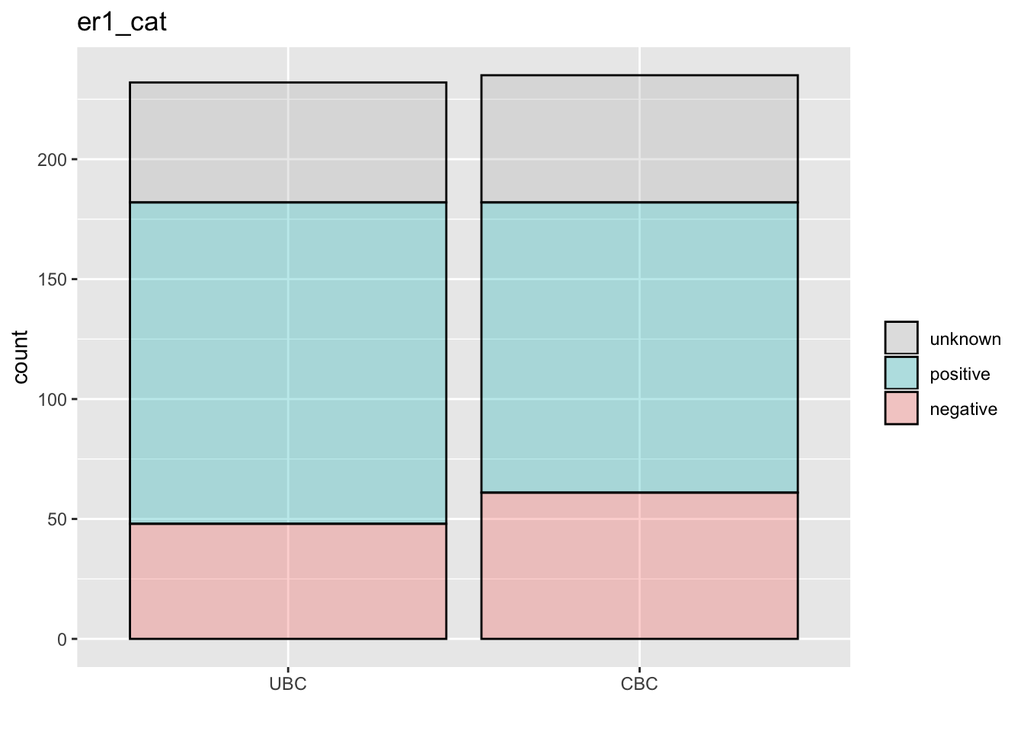

```r
ggplot(phenotypes.df) +
  aes(as.factor(cc), fill=factor(phenotypes.df$er1_cat,
                                 levels=c("unknown", "positive", "negative"))) +
  geom_bar(colour="black", alpha=0.3) +
  scale_x_discrete(name ="", labels=c("0" = "UBC", "1" = "CBC")) +
  scale_fill_manual(name="",
    values = c("negative"="#F8766D",
                "unknown"="grey",
                "positive"="#00BFC4")) +
  ggtitle("er1_cat")
```

```r
chisq.test(x,simulate.p.value=TRUE)
```

```
##
##  Pearson's Chi-squared test with simulated p-value (based on 2000
##  replicates)
##
## data:  x
## X-squared = 2.2814, df = NA, p-value = 0.3253
```

```r
fisher.test(x,simulate.p.value=TRUE)
```

```
##
##  Fisher's Exact Test for Count Data with simulated p-value (based
##  on 2000 replicates)
##
## data:  x
## p-value = 0.3438
## alternative hypothesis: two.sided
```

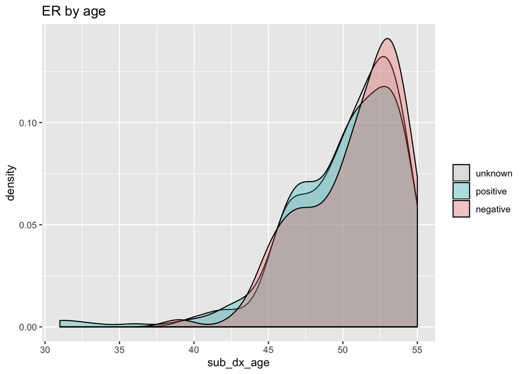

```r
ggplot(phenotypes.df) +
  aes(x = sub_dx_age, fill=factor(phenotypes.df$er1_cat,
                                 levels=c("unknown", "positive", "negative"))) +
  geom_density(colour="black", alpha=0.3) +
  scale_fill_manual(name="",
    values = c("negative"="#F8766D",
                "unknown"="grey",
                "positive"="#00BFC4")) +
  ggtitle("ER by age")
```

```r
rm(x)
```

## pr1_cat

PgR were virtually identical in CBC and UBC

```r
summary(as.factor(phenotypes.df$pr1_cat))
```

```
## negative positive  unknown
##      102      210      155
```

```r
x <- table(phenotypes.df[,c("cc","pr1_cat")])
x
```

```
##    pr1_cat
## cc  negative positive unknown
##   0       50      104      78
##   1       52      106      77
```

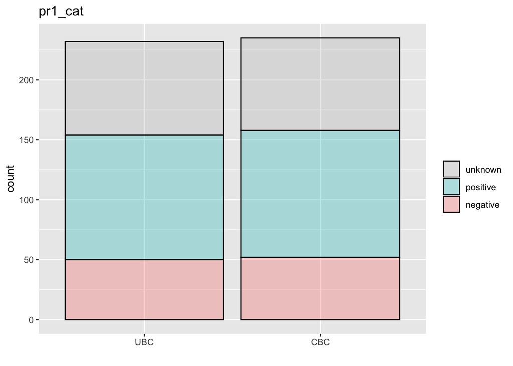

```r
ggplot(phenotypes.df) +
  aes(as.factor(cc), fill=factor(phenotypes.df$pr1_cat,
                                 levels=c("unknown", "positive", "negative"))) +
  geom_bar(colour="black", alpha=0.3) +
  scale_x_discrete(name ="", labels=c("0" = "UBC", "1" = "CBC")) +
  scale_fill_manual(name="",
    values = c("negative"="#F8766D",
                "unknown"="grey",
                "positive"="#00BFC4")) +
  ggtitle("pr1_cat")
```

```r
chisq.test(x,simulate.p.value=TRUE)
```

```
##
##  Pearson's Chi-squared test with simulated p-value (based on 2000
##  replicates)
##
## data:  x
## X-squared = 0.045445, df = NA, p-value = 0.9765
```

```r
fisher.test(x,simulate.p.value=TRUE)
```

```
##
##  Fisher's Exact Test for Count Data with simulated p-value (based
##  on 2000 replicates)
##
## data:  x
## p-value = 0.9785
## alternative hypothesis: two.sided
```

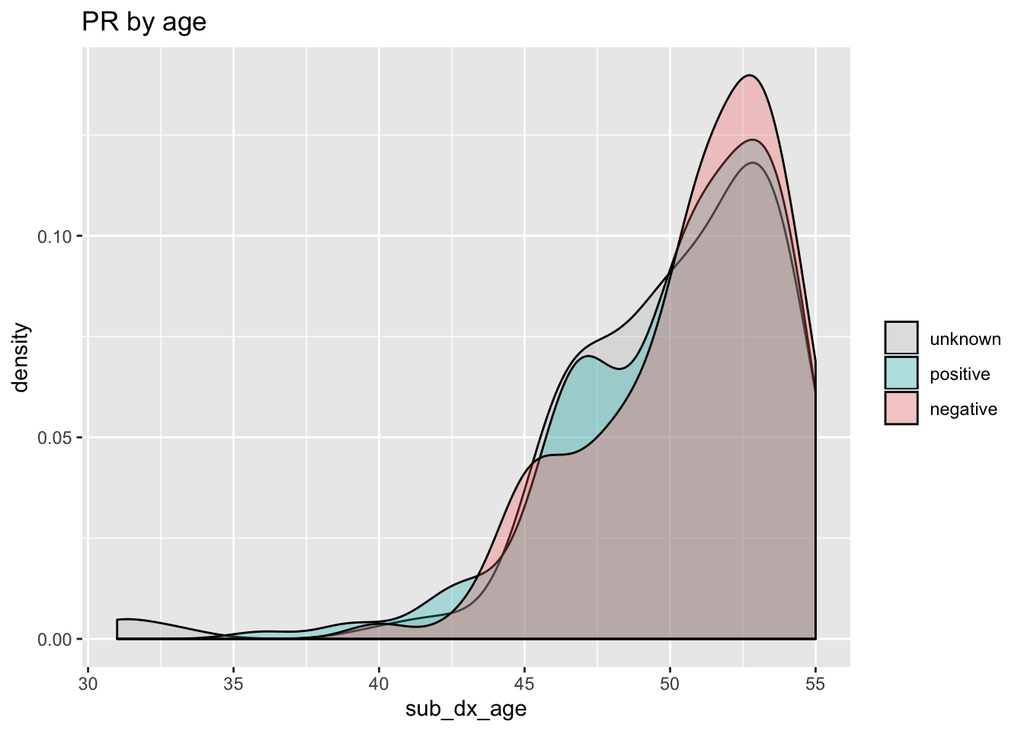

```r
ggplot(phenotypes.df) +
  aes(x = sub_dx_age, fill=factor(phenotypes.df$pr1_cat,
                                 levels=c("unknown", "positive", "negative"))) +
  geom_density(colour="black", alpha=0.3) +
  scale_fill_manual(name="",
    values = c("negative"="#F8766D",
                "unknown"="grey",
                "positive"="#00BFC4")) +
  ggtitle("PR by age")
```

```r
rm(x)
```

## Er & PgR

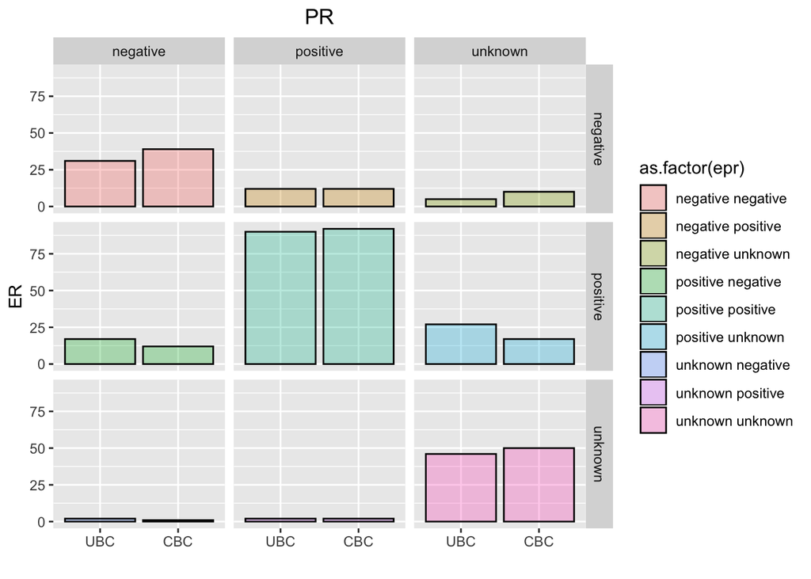

```r
phenotypes.df <- phenotypes.df %>% mutate(epr=paste(er1_cat, pr1_cat))

ggplot(phenotypes.df) +
  aes( as.factor(cc), fill=as.factor(epr)) +
  geom_bar(colour="black", alpha=0.3) +
  scale_x_discrete(name ="", labels=c("0" = "UBC", "1" = "CBC")) +
  facet_grid(er1_cat~pr1_cat) +
  ylab("ER") +
  ggtitle ("PR")+
  theme(plot.title = element_text(hjust = 0.5))
```

# Pathology

## grade1

NS trend to less differentiated tumours in CBC

```r
summary(as.factor(phenotypes.df$grade1))
```

```
##              moderate poor/undifferentiated               unknown
##                   131                    93                   158
##                  well
##                    85
```

```r
x <- table(phenotypes.df[,c("cc","grade1")])
x
```

```
##    grade1
## cc  moderate poor/undifferentiated unknown well
##   0       65                    40      85   42
##   1       66                    53      73   43
```

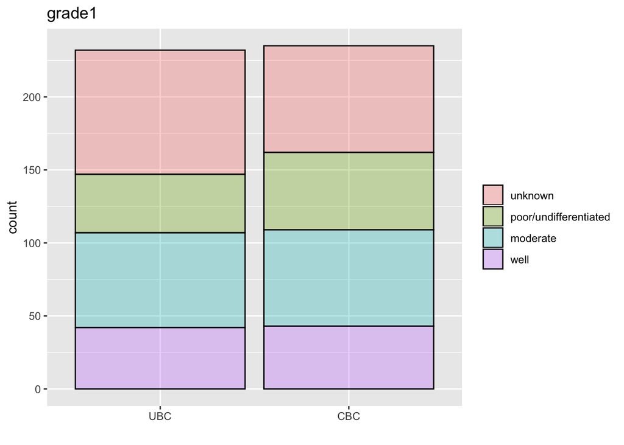

```r
ggplot(phenotypes.df) +
  aes(as.factor(cc), fill=factor(phenotypes.df$grade1,
                                 levels=c("unknown","poor/undifferentiated","moderate","well"))) +
  geom_bar(colour="black", alpha=0.3) +
  scale_x_discrete(name ="", labels=c("0" = "UBC", "1" = "CBC")) +
  scale_fill_discrete(name="") +
  ggtitle("grade1")
```

```r
chisq.test(x,simulate.p.value=TRUE)
```

```
##
##  Pearson's Chi-squared test with simulated p-value (based on 2000
##  replicates)
##
## data:  x
## X-squared = 2.7288, df = NA, p-value = 0.4358
```

```r
fisher.test(x,simulate.p.value=TRUE)
```

```
##
##  Fisher's Exact Test for Count Data with simulated p-value (based
##  on 2000 replicates)
##
## data:  x
## p-value = 0.4218
## alternative hypothesis: two.sided
```

```r
rm(x)
```